# Can We Predict Mental Illness Based on Musical Taste?

## 1. Motivation

Having a background in psychology and having played guitar for over 15 years, music and mental health are two topics near and dear to me. It's well known that mental disorders affect millions worldwide, and their impact on individuals and society is significant. While the causes of mental disorders are complex and multifaceted, researchers have long recognized that environmental factors, such as social and cultural influences, can play a role in their development. Recently, there has been increasing interest in the potential link between music and mental health. Studies have shown that music can profoundly affect our emotional and psychological well-being, and it has been suggested that individuals with certain mental disorders may have distinct music preferences and behaviors related to music consumption.

This research paper will explore the relationship between mental disorders and music taste and how this relationship can be predicted using machine learning algorithms. Specifically, I will examine whether there are patterns in the music preferences and streaming behaviors of individuals with different mental disorders and whether these patterns can be used to develop accurate predictive models.

To do so, I will rely on the MxMT (Music x Mental Health Traits) dataset, which is a survey dataset that contains responses from over 700 individuals about their music preferences and mental health traits.

- Data collection was managed via a Google Form.
- Respondents were not restricted by age or location.
- The form was posted in various Reddit forums, Discord servers, and social media platforms.
- Posters and "business cards" were also used to advertise the form in libraries, parks, and other public locations.
- The survey was active from August to November 2022.
- The data can be freely accessed on Kaggle: https://www.kaggle.com/datasets/catherinerasgaitis/mxmh-survey-results

The dataset was created to explore the relationship between music and mental health and has been used in various research studies and machine-learning projects. In this regard, I will develop my model to advance our understanding of music and its role in mental health.

## 2. Exploratory Data Analysis

```python
import numpy as np # linear algebra
import pandas as pd # data processing, CSV file I/O (e.g. pd.read_csv)
import matplotlib.pyplot as plt # fundamental visualization
import seaborn as sns # advanced visualization built on top of matplotlib
```

```python
df = pd.read_csv("mxmh_survey_results.csv")
```

```python
df.head()
```

|  | Timestamp | Age | Primary streaming service | Hours per day | While working | Instrumentalist | Composer | Fav genre | Exploratory | Foreign languages | ... | Frequency [R&B] | Frequency [Rap] | Frequency [Rock] | Frequency [Video game music] | Anxiety | Depression | Insomnia | OCD | Music effects | Permissions |
| --- | --- | --- | --- | --- | --- | --- | --- | --- | --- | --- | --- | --- | --- | --- | --- | --- | --- | --- | --- | --- | --- |
| 0 | 8/27/2022 19:29:02 | 18.0 | Spotify | 3.0 | Yes | Yes | Yes | Latin | Yes | Yes | ... | Sometimes | Very frequently | Never | Sometimes | 3.0 | 0.0 | 1.0 | 0.0 | NaN | I understand. |
| 1 | 8/27/2022 19:57:31 | 63.0 | Pandora | 1.5 | Yes | No | No | Rock | Yes | No | ... | Sometimes | Rarely | Very frequently | Rarely | 7.0 | 2.0 | 2.0 | 1.0 | NaN | I understand. |
| 2 | 8/27/2022 21:28:18 | 18.0 | Spotify | 4.0 | No | No | No | Video game music | No | Yes | ... | Never | Rarely | Rarely | Very frequently | 7.0 | 7.0 | 10.0 | 2.0 | No effect | I understand. |
| 3 | 8/27/2022 21:40:40 | 61.0 | YouTube Music | 2.5 | Yes | No | Yes | Jazz | Yes | Yes | ... | Sometimes | Never | Never | Never | 9.0 | 7.0 | 3.0 | 3.0 | Improve | I understand. |
| 4 | 8/27/2022 21:54:47 | 18.0 | Spotify | 4.0 | Yes | No | No | R&B | Yes | No | ... | Very frequently | Very frequently | Never | Rarely | 7.0 | 2.0 | 5.0 | 9.0 | Improve | I understand. |

5 rows × 33 columns

```python
print(list(df))
```

[output not shown]

```python
df.dtypes
```

[output not shown]

```python
df.describe()
```

|  | Age | Hours per day | BPM | Anxiety | Depression | Insomnia | OCD |
| --- | --- | --- | --- | --- | --- | --- | --- |
| count | 735.000000 | 736.000000 | 6.290000e+02 | 736.000000 | 736.000000 | 736.000000 | 736.000000 |
| mean | 25.206803 | 3.572758 | 1.589948e+06 | 5.837636 | 4.796196 | 3.738451 | 2.637228 |
| std | 12.054970 | 3.028199 | 3.987261e+07 | 2.793054 | 3.028870 | 3.088689 | 2.842017 |
| min | 10.000000 | 0.000000 | 0.000000e+00 | 0.000000 | 0.000000 | 0.000000 | 0.000000 |
| 25% | 18.000000 | 2.000000 | 1.000000e+02 | 4.000000 | 2.000000 | 1.000000 | 0.000000 |
| 50% | 21.000000 | 3.000000 | 1.200000e+02 | 6.000000 | 5.000000 | 3.000000 | 2.000000 |
| 75% | 28.000000 | 5.000000 | 1.440000e+02 | 8.000000 | 7.000000 | 6.000000 | 5.000000 |
| max | 89.000000 | 24.000000 | 1.000000e+09 | 10.000000 | 10.000000 | 10.000000 | 10.000000 |

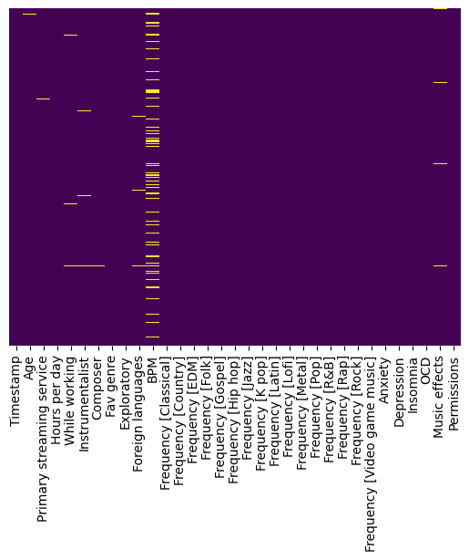

```python
# assessing null values
sns.heatmap(df.isnull(), yticklabels=False, cbar=False, cmap='viridis')
```

```
array([[<AxesSubplot:title={'center':'Age'}>,
        <AxesSubplot:title={'center':'Hours per day'}>,
        <AxesSubplot:title={'center':'BPM'}>],
       [<AxesSubplot:title={'center':'Anxiety'}>,
        <AxesSubplot:title={'center':'Depression'}>,
        <AxesSubplot:title={'center':'Insomnia'}>],
       [<AxesSubplot:title={'center':'OCD'}>, <AxesSubplot:>,
        <AxesSubplot:>]], dtype=object)
```

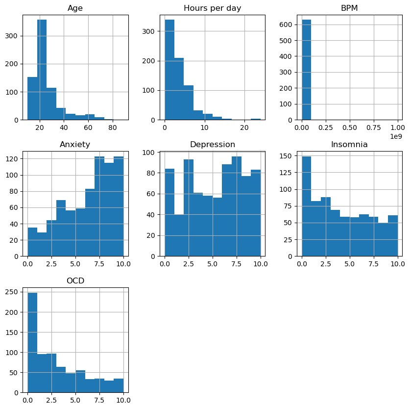

```python
df.hist(figsize=(10, 10), bins=10)
```

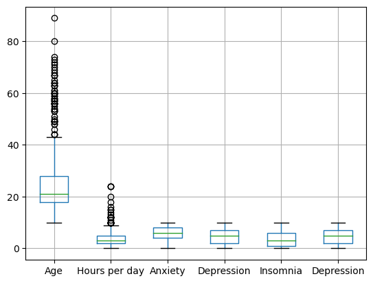

```python
# create a boxplot of all columns
df[['Age', 'Hours per day', 'Anxiety', 'Depression', 'Insomnia', 'Depression']].boxplot()

# display the plot
plt.show()
```

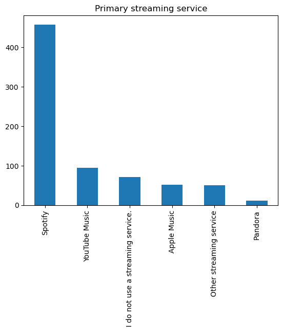

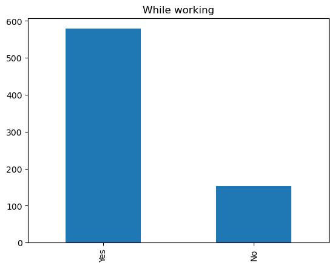

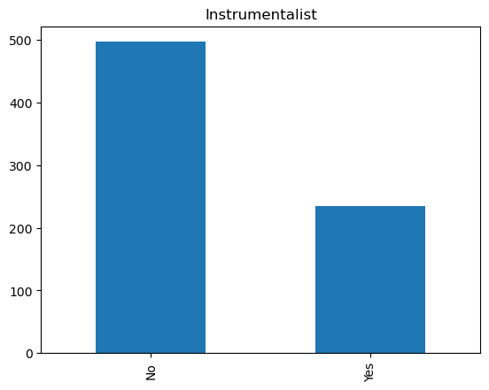

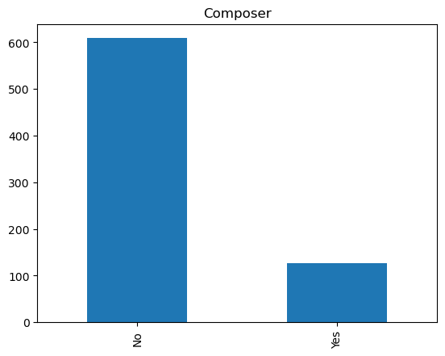

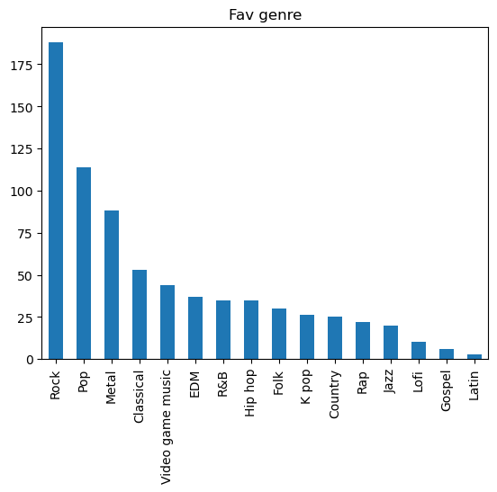

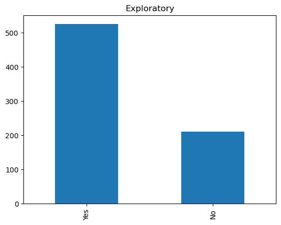

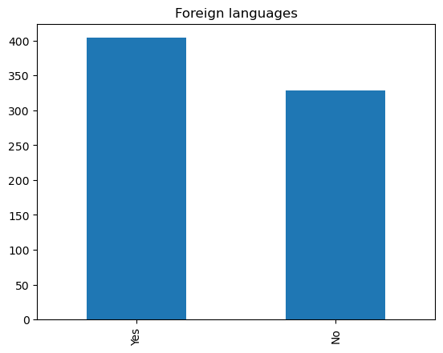

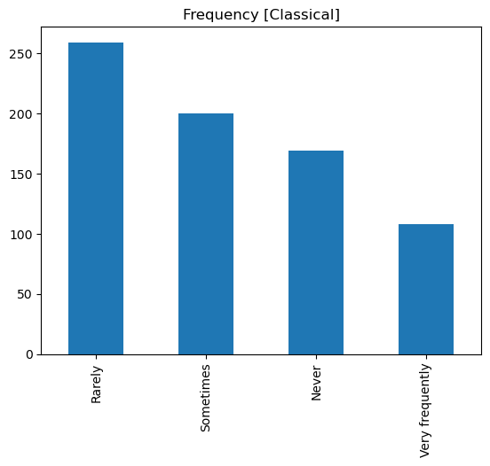

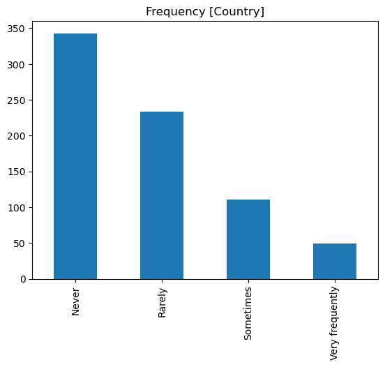

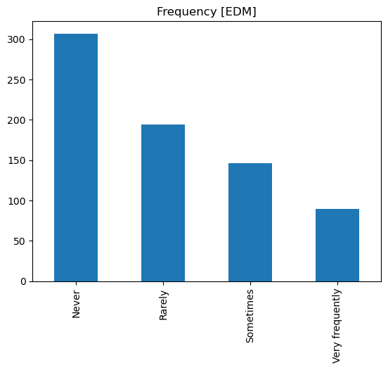

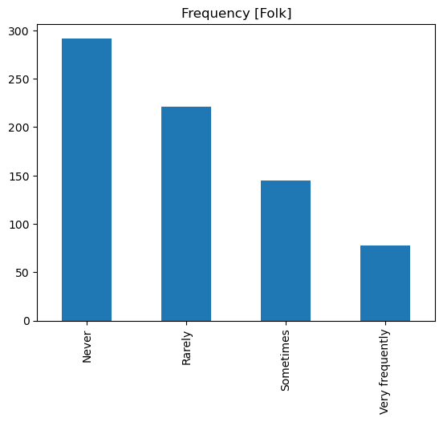

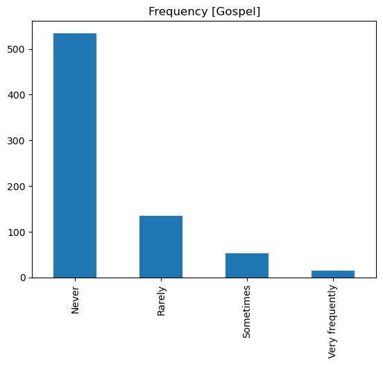

[13 more figures not shown]

```python
# loop through all columns in the dataframe
for column in df.columns:
    # skip the 'Timestamp' column
    if column == 'Timestamp':
        continue
    # check if the column is not of data type float64
    if df[column].dtype != 'float64':
        # create a bar plot of the value counts for non-float64 columns
        counts = df[column].value_counts()
        counts.plot(kind='bar')
        plt.title(column)  # add a title with the name of the column
        plt.show()
```